# Презентация к лабораторной работе 2

Выполнение

Власов Артем Сергеевич

1132246841@rudn.ru

Российский университет дружбы народов

# Информация

## Докладчик

- Власов Артем Сергеевич
- Студент
- Студент
- Российский университет дружбы народов им. П. Лумумбы
- 1132246841@rudn.ru
- https://vlasovas52.github.io/ru/

# Вводная часть

## Цели и задачи

Выполнить действия по созданию и управлению групп и учетных записей пользователей с помощью командной строки. Научиться создавать новые учетные записи и группы, добавлять учетные записи в группы, задавать им определенные права, ответить на контрольные вопросы.

# Выполнение лабораторной работы 2

Получим информацию о нашем пользователе.

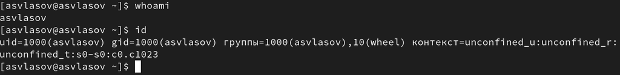

Пользователь

Посмотрим информацию о root учетной записи.

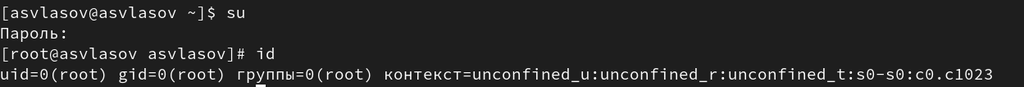

Рут

Проверяем строчку wheel в файле. Группа wheel это группа пользователей с правами администратора системы.

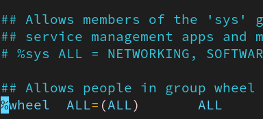

wheel

Создаем пользователя alice и сразу добавляем его в группу администраторов, задаем пароль для учетной записи.

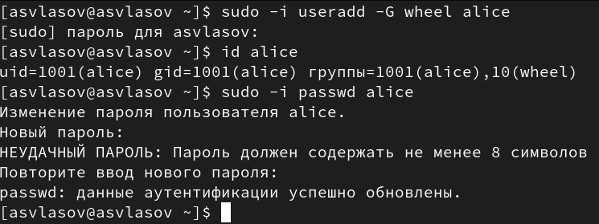

Новый пользователь

Переключаемся на пользователя администратора aliceи создаем нового пользователя bob.

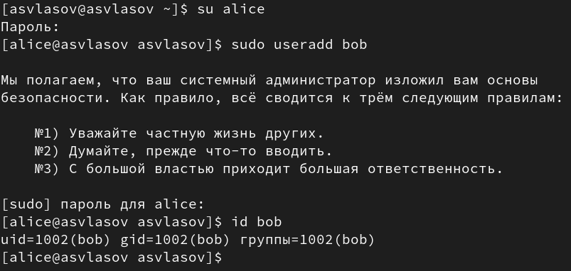

БОБ

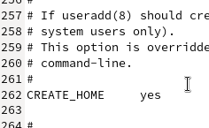

1

Добавляем в папку skel директории картинок и документов, чтобы они были у каждого нового пользователя.

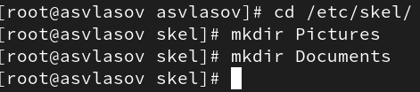

Добавление директорий

Задаем gedit, как редактор файлов по умолчанию.

Создаем нового пользователя carol и задаем ему пароль.

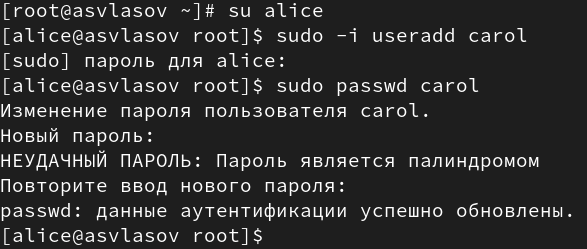

Новый пользовательь

Переходим в нового пользователя, и читаем информацию о нем.

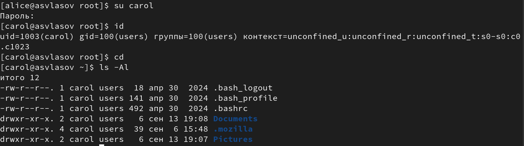

Информация пользователя

Смотрим пароль пользователя. Меняем данные для пароля.

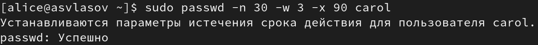

Изм пароль

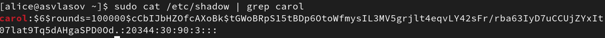

Проверяем

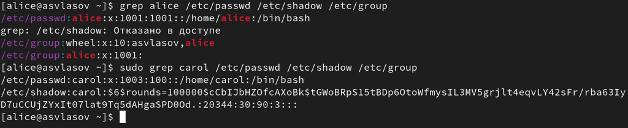

Идентификатор

Создаем две новых группы main и third.

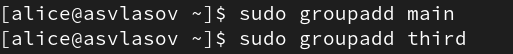

Группы

Добавляем пользователей в группы, и проверяем данные о пользователях.

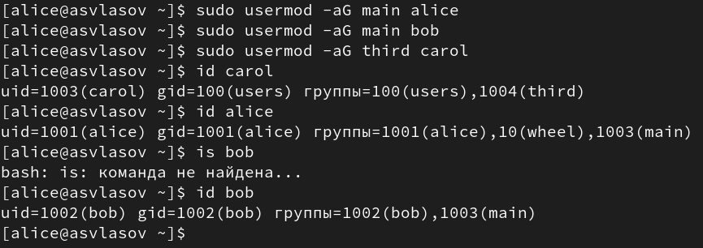

Группы.

# Выводы

[figure not shown]